# Métodos de recolección y organización de datos

En el control de calidad, es importante la gestión basada en hechos; para ello, es necesario recogerlos datos de manera correcta y procesarlos eatadístticamente.

```python
import os

try:
  os.chdir('../Python/QCKentei3')
except:
  pass

path = os.getcwd()
```

## 01-01 Tipos de datos

### 1. Qué son los datosy y tipos de datos

- **Valore medido**: Es el dato obtenido a través de la medición, que toma valores continuos.
- **Valor continuo**: Es un estado en el que existen infinitos valores de manera continua.
- **Valor contado**: Es el dato obtenido mediante el conteo, que toma valores discontinuos.
- **Discontinuo**: Es algo que toma valores discretos, como el número de productos no conformes, que puede ser 1, 2, ... y así sucesivamnte.
- **Datos de clasificación**: Son datos en los que no existe una relación de orden o tamaño entre las categorías, como en el caso de los grupos sanguíneos tipo ABO. Existen tembién datos de clasificación ordinal, en los cuales se define una relación de orden entre las categorías, como cuando se clasifica un producto en primer aclase, segunda clase, etc.
- **Datos ordinales**: Son datos medidos en función de una clasificación, como las posiciones en una marató o los resultados de un concurso de música, donde se ordenan según el punto, como el primero, segundo , etc.
- **Datos ligüisticos**: Son información lingüístcica que no puede ser cuantificada. Un método para manejar datos lingüísticos es el uso de las siete herramientas del control de calidad (QC)

### 2. Transformación de datos

## 01-02 Población muestra

### 1. Qué es la población y qué es la muestra

#### (1) Objetivo de recoger datos

- Para análisis (evaluación del estado actual, análisis de factores)
- Para gestión
- Para inspección

#### (2) Población y muestra

- **Población**: Es el grupo sobre el cual se toma acción o se realiza un tratamiento basado en observaci´nes o datos.
- **Muestra**: Es un subconjunto extraído de la población con el propósito de obtener información sobre ella y tomar acciones o decisiones sobre la población.
- **Muestreo**: Es le proceso de estraer una muestra de la población.
- Población infinita
- Población finita

## 01-03 Muestreo y error

### 1. Qué es el muestreo aleatorio

- Muestreo aleatorio: Es un tipo de muestreo en el cual todos los elementos que conforman la población tienen la misma probabilidad de ser seleccionados como muestra, y no se realiza de manera arbitraria o intencional.
- Método de muestreo dos etapas
- Método de muestreo estrarificado
- Método de muestreo por conglomerados
- Método por juicio

### 2. Qué es el error

- La variabilidad de los datos = La variabilidad del proceso + Error de muestreo + Error de medición
- Causas asignables
- Causas aleatorias

## 01-04 Estadísticas descriptivas

### 1. Estadísticas descriptivas

- Al resumir datos de una muestra, expresarlos en valores cuantitativos permite realizar juicios objetivos, comparaciones y estimaciones.

Estos valores cuantitativos se denominan **estadísticos**, y entre ellos, los más fundamentales se conocen como **estadísticos básicos.**

### 2. Estadísticas descriptivas que representan el centro de la distribución

#### (1) Media

- Media: La estadística más fundamental.

  $ \bar{x} = \frac{1}{n} \sum x_i $

#### (2) Mediana

- Mediana: ES el valor **central cuando** los datos obtenidos se ordenan en orden de magnitud.
- Cuando el número de datos es impar, se toma el valor central, cuando es par, se toma el promedio de los dos valores centrales.

### 3. Estadística descriptivas que representan la dispersión de la distribución

#### (1) Suma de los cuadrados (S)

- La suma de los cuadrados de las desviaciones se llama **suma de cuadrados** (suma de cuadrados de las desviaciones) y se denota como $ S $.

  $ S = \sum (x_i - \bar{x})^2 $

#### (2) Varianza (V)

- Como una media que no se ve afectada por el número de datatos, se utiliza la varianza $ V $.

  $ V = \frac{1}{n-1} \sum (x_i - \bar{x})^2 $

#### (3) Desviación estándar (s)

- Desviación estándar: Se expresa como la raíz cuadrada de la varianza $ V $.

  $ s = \sqrt{V} $

#### (4) Rango (R)

- Ladiferencia entre el valor máximo y el valor minimo en los datos se llama Rango $ R $.

  $ R = x_{max} - x_{min} $

#### (5) Coeficiente de variación (CV)

- La relación entre la desviación estándar y la media se llama coeficiente de variación $ CV $ y se expresa en porcentaje.

  $ CV = s / \bar{x} \times100 $ %

```python
# Gráfico de distribución normal

import numpy as np
import matplotlib.pyplot as plt
from scipy.stats import norm

# Configuración de parámetros
mu = 0      # Media
sigma = 1   # Desviación estándar

x = np.linspace(mu - 4*sigma, mu + 4*sigma, 1000)
pdf = norm.pdf(x, mu, sigma)

#
plt.figure(figsize=(8, 4))
plt.plot(x, pdf, color='blue')

plt.axvline(mu, color='red', linestyle='dashed', label='Mean')
plt.axvline(mu - sigma, color='gray', linestyle='dashed', label='Mu - Sigma')
plt.axvline(mu + sigma, color='gray', linestyle='dashed', label='Mu + Sigma')

plt.legend()
plt.xlabel('x')
plt.ylabel('Probability Density')
plt.title('Normal Distribution')

plt.show()
```

[output not shown]

## 1-1

電子部品を製造している工程から６個サンプルを採取し、下記の出力電流 $ (mA) $ を測定した。平均値 $ \bar{x} $、メディアン $ \tilde{x} $、平方和 $ S $、分散 $ V $ 、標準偏差 $ s $、 範囲 $ R $ 、変動係数 $ CV $ をもとめよ。

Se tomaron 6 muestras del proceso de fabricación de componentes electrónicos y se midió la corriente de salida $ (mA) $ a continuación. Calcule la media $ \bar{x} $, la meiana $ \tilde{x} $, la suma de los cuadrados $ S $, la varianza $ V $, la disviación estándar $ s $, el rango R y el coeficiente de variación $ CV $.

[29.2, 27.0, 31.6, 29.6, 33.4, 30.5]

```
\Media (x̄): 30.22 mA
Mediana (x̃): 30.05 mA
Suma de cuadradas (S): 23.89
Varianza (V): 4.78 mA^2
Desviación estándar (s): 2.19 mA
Rango (R): 6.40 mA
Coeficiente de variación (CV): 7.23%
```

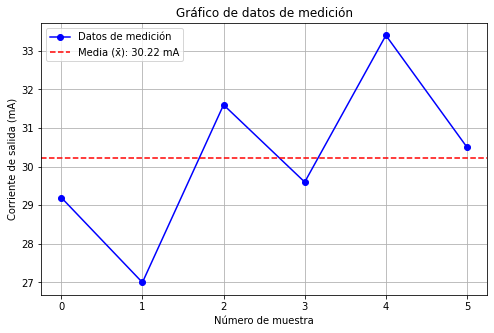

```
sorted data
[27.0, 29.2, 29.6, 30.5, 31.6, 33.4]
```

```python
# Datos de medición
data = [29.2, 27.0, 31.6, 29.6, 33.4, 30.5]

# Ordenar los datos
sorred_arr = sorted(data)

# Media
mean = np.mean(data)

# Mediana
median = np.median(data)

# Suma de cuadrados
sum_of_squares = np.sum((data - mean)**2)

# Varianza
variance = np.var(data, ddof=1)

# Desviación estándar
std_dev = np.std(data, ddof=1)

# Rango
range_value = np.max(data) - np.min(data)

# Coeficente de variación
cv = std_dev / mean * 100

# 結果をプリント
print(f"\Media (x̄): {mean:.2f} mA")
print(f"Mediana (x̃): {median:.2f} mA")
print(f"Suma de cuadradas (S): {sum_of_squares:.2f}")
print(f"Varianza (V): {variance:.2f} mA^2")
print(f"Desviación estándar (s): {std_dev:.2f} mA")
print(f"Rango (R): {range_value:.2f} mA")
print(f"Coeficiente de variación (CV): {cv:.2f}%")

# Creación de gráficos
plt.figure(figsize=(8, 5))
plt.plot(data, marker='o', linestyle='-', color='b', label="Datos de medición")
plt.axhline(mean, color='r', linestyle='--', label=f"Media (x̄): {mean:.2f} mA")
plt.title("Gráfico de datos de medición")
plt.xlabel("Número de muestra")
plt.ylabel("Corriente de salida (mA)")
plt.legend()
plt.grid(True)
plt.show()

print('sorted data')
print(sorred_arr)
```

## 1-2

ある部品の重要特性である厚さについて、製造工程のラインAとラインBで違いがあるかどうかを調査することになり、下記のデータを得た。

ラインAは、データの数が10、データの合計が474、平方和が、112.40 ラインBは、データの数が9, データの合計が450、平方和が106.00

ラインAとラインBの平均値、標準偏差、変動係数の大小関係を比較せよ。

Se ha decidido investgar si existe una diferencía en el espeso, una característica crítica de un determinado componente, enter la línea de producción A y la línea de producción B. Se han obtenido los siguientes datos:

- Línea A: cantidad de datos = 10, suma de los datos = 474, suma de cuadrados = 112.40
- Linea B: cantidad de datos = 9, suma de los datos = 450, suma de cuadrados = 106.00

Compare el orden de magnitud enter la media, la desviación estándar y el coeficiente de variación de la líea A y la línea B

```python
import pandas as pd

# Número de datos, Suma de los datos, Suma de los cuarados
# Linea A
n_A, sum_A, ss_A = 10, 474, 112.40
# Linea B
n_B, sum_B, ss_B = 9, 450, 106.00

# Cálculo de la media
mean_A = sum_A / n_A
mean_B = sum_B / n_B

# Cálculo de la varianza
var_A = ss_A / (n_A - 1)
var_B = ss_B / (n_B - 1)

# Cálculo de la desviación estándar
std_A = np.sqrt(var_A)
std_B = np.sqrt(var_B)

# Cálculo del coeficiente de variación
cv_A = (std_A / mean_A) * 100
cv_B = (std_B / mean_B) * 100

# Resumir los resultados en una tabla
data = {
    "Elemento": ["Número de datos","Media","Suma de cuadrados","Varianza", "Desviación estandar", "Coeficiente da variación"],
    "Linea A": [n_A,mean_A, ss_A, var_A, std_A, cv_A],
    "Linea B": [n_B,mean_B, ss_B, var_B, std_B, cv_B]
}
df = pd.DataFrame(data)
df = df.round(3)

df
```

|  | Elemento | Linea A | Linea B |
| --- | --- | --- | --- |
| 0 | Número de datos | 10.000 | 9.00 |
| 1 | Media | 47.400 | 50.00 |
| 2 | Suma de cuadrados | 112.400 | 106.00 |
| 3 | Varianza | 12.489 | 13.25 |
| 4 | Desviación estandar | 3.534 | 3.64 |
| 5 | Coeficiente da variación | 7.456 | 7.28 |

La media es mayor en la línea B

La suma de los cuadrados es mayor en la línea A

La desviación estándar es mayor en la línea B

El coeficiente de variación es mayor en la la línea A

```python
notebook_name = 'QCKentei3-1.ipynb'
notebook_name_html = notebook_name.replace(".ipynb",".html")

!jupyter nbconvert --to html {notebook_name}
!mv {notebook_name_html} ../html/
```

```
[NbConvertApp] Converting notebook QCKentei3-1.ipynb to html
[NbConvertApp] Writing 664310 bytes to QCKentei3-1.html
mv: rename QCKentei3-1.html to ../html/: No such file or directory
```